# Exercise 2: Practicing ggplot2

Load required libraries, the `msleep` dataset, and set the output directory.

```r
library(ggplot2)

data(msleep)

# output dir
dir <- file.path("exer_2")
```

## Question 1: Basic scatterplot with the msleep dataset

Create a scatterplot showing the relationship between `bodywt` (body weight) and `brainwt` (brain weight). Add appropriate axis labels and change the theme to `theme_classic()`.

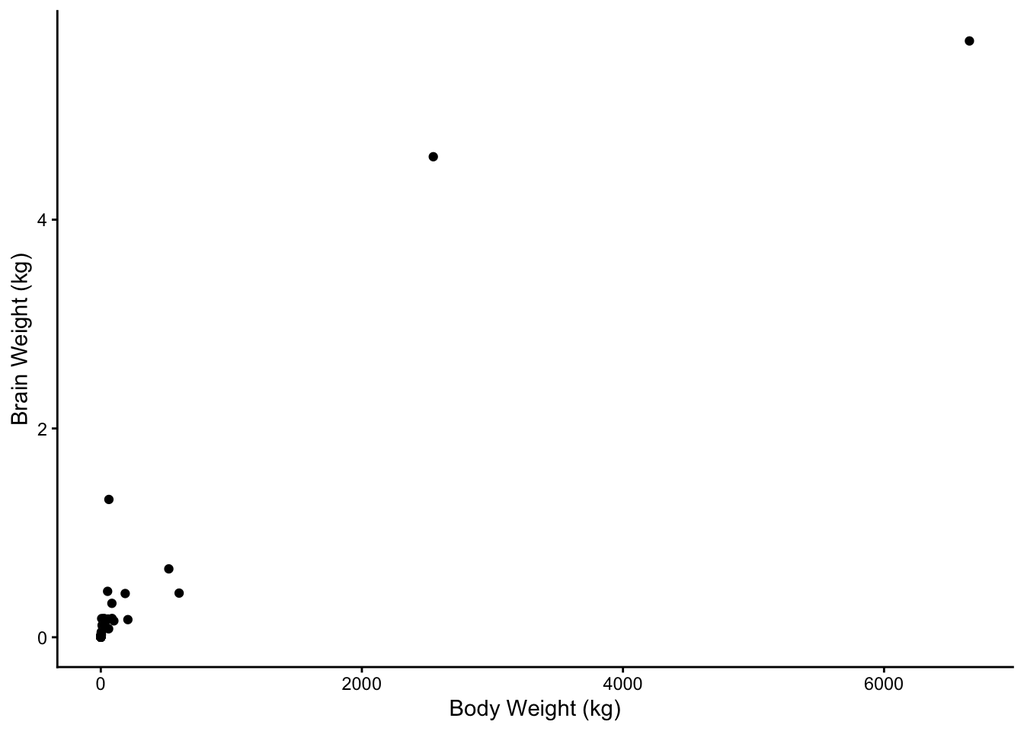

```r
plot1 <- ggplot(msleep, aes(x=bodywt, y=brainwt)) +
  geom_point(na.rm=TRUE) +
  labs(x="Body Weight (kg)", y="Brain Weight (kg)") +
  theme_classic()
ggsave(file.path(dir, "plot1.jpeg"), plot1)
plot1
```

## Question 2: Adding color by group

Using the same variables from question 1 (`bodywt` and `brainwt`), color the points by `vore` (diet type). Make sure to convert `vore` to a factor. Add a legend title that says “Diet Type”.

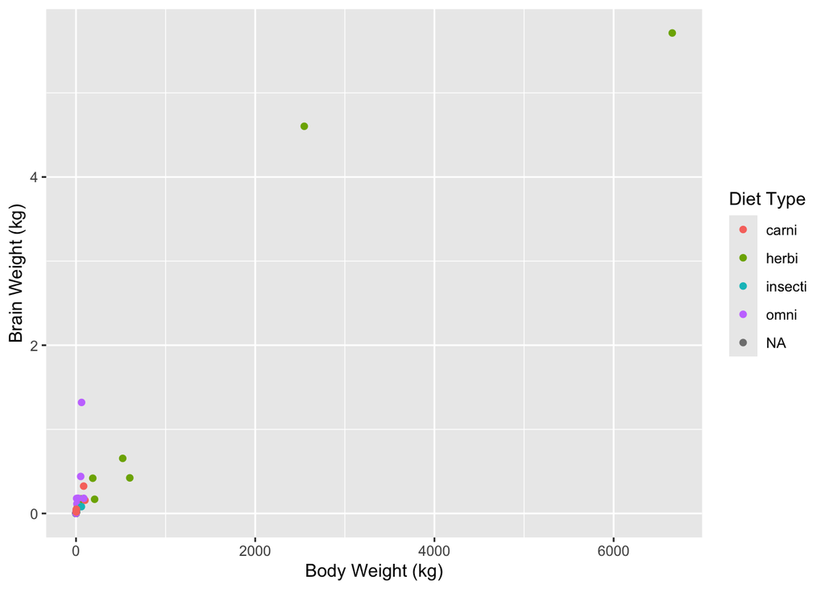

```r
plot2 <- ggplot(msleep, aes(x=bodywt, y=brainwt)) +
  geom_point(aes(color=as.factor(vore)), na.rm=TRUE) +
  labs(x="Body Weight (kg)", y="Brain Weight (kg)", color="Diet Type")
ggsave(file.path(dir, "plot2.jpeg"), plot2)
plot2
```

## Question 3: Scatterplot with a line of best fit

Plot `sleep_total` against `sleep_cycle`. Add a linear regression line using `geom_smooth()`. Color the line red and use `theme_minimal()`.

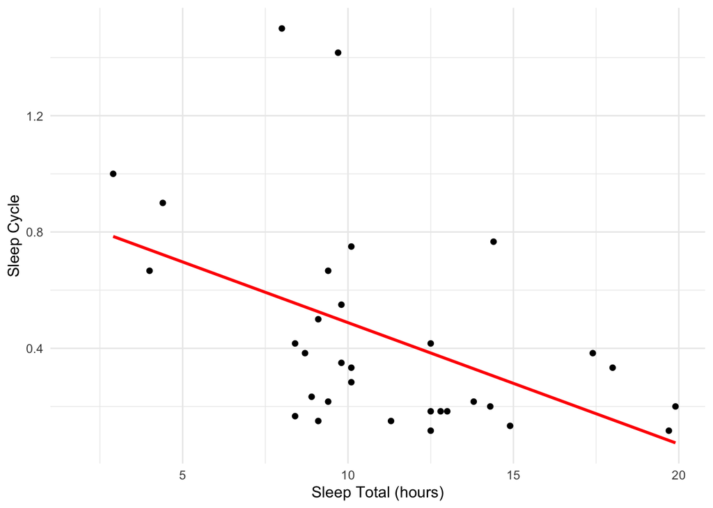

```r
plot3 <- ggplot(msleep, aes(x=sleep_total, y=sleep_cycle)) +
  geom_point(na.rm=TRUE) +
  geom_smooth(method="lm", color="red", se=FALSE, na.rm=TRUE) +
  labs(x="Sleep Total (hours)", y="Sleep Cycle") +
  theme_minimal()
ggsave(file.path(dir, "plot3.jpeg"), plot3)
plot3
```

## Question 4: Faceted plots by group

Create a scatterplot of `sleep_total` vs `sleep_rem`. Use `facet_wrap()` to create separate panels for each `vore` type. Add appropriate axis labels.

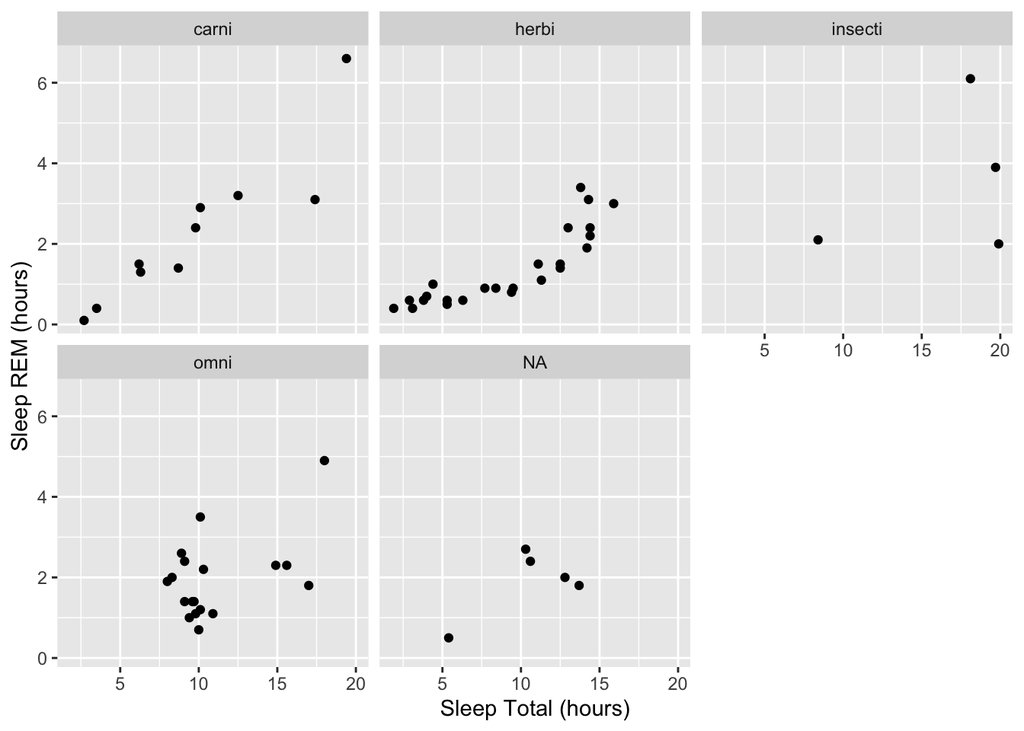

```r
plot4 <- ggplot(msleep, aes(x=sleep_total, y=sleep_rem)) +
  geom_point(na.rm=TRUE) +
  facet_wrap(~vore) +
  labs(x="Sleep Total (hours)", y="Sleep REM (hours)")
ggsave(file.path(dir, "plot4.jpeg"), plot4)
plot4
```

## Question 5: Exploring a new dataset

Load the built-in `iris` dataset. Create a scatterplot showing `Petal.Length` vs `Petal.Width`. Color points by `Species`. Add a title to your plot using `ggtitle("Iris Petal Dimensions")`. Choose your favorite theme.

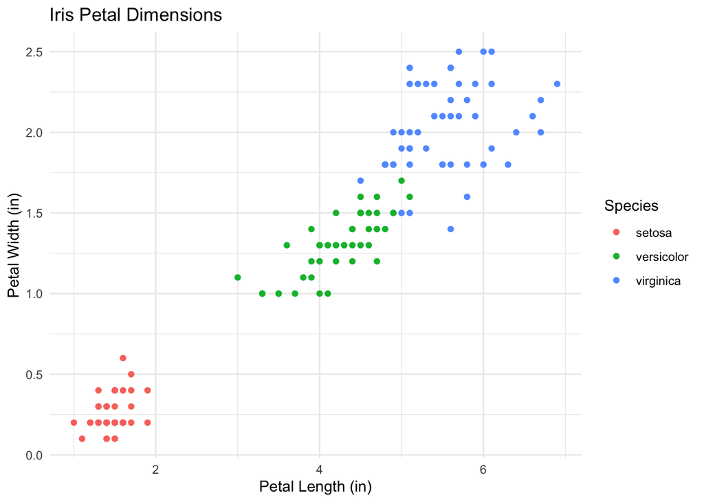

```r
data(iris)

plot5 <- ggplot(iris, aes(x=Petal.Length, y=Petal.Width)) +
  geom_point(aes(color=as.factor(Species)), na.rm=TRUE) +
  labs(title="Iris Petal Dimensions", x="Petal Length (in)", y="Petal Width (in)", color="Species") +
  theme_minimal()
ggsave(file.path(dir, "plot5.jpeg"), plot5)
plot5
```

## Bonus Challenge (Optional)

Pick any two continuous variables from the `msleep` dataset and create a publication-quality plot with:

- Appropriate axis labels
- A theme of your choice
- Points colored by a grouping variable
- A descriptive title